# network

# networking

### networking: enable machine-to-machine communication

- goal: enable *applications* that span multiple computers
  - websites
  - streaming video
  - email
  - chat
  - …
- challenge: realities of the real-world
  - massive scale
  - consequences of success
  - security
  - geopolitical and economic concerns

### sockets is the de-facto API for networking

- open *connection* then …
  - read+write just like a terminal file
- doesn’t look like individual messages
- ‘‘connection abstraction’’

### mailbox model

- *mailbox* abstraction: send/receive messages

[figure not shown]

### connections over mailboxes

- real Internet: mailbox-style communication
  - send ‘‘letters’’ (packets) to particular mailboxes
  - have ‘‘envelope’’ (header) saying where they go
- ‘‘best-effort’’
  - no guarantee on order, when received
  - no guarantee on *if* received
- sockets implemented on top of this

### connections

[figure not shown]

### networking layers

| application | HTTP, SSH, SMTP, … | application-defined meanings |
| --- | --- | --- |
| transport | TCP, UDP, … | reach correct program reliability/streams |
| network | IPv4, IPv6 | reach correct machine (across networks) |
| link | Ethernet, Wi-Fi, … | coordinate shared wire/radio |
| physical | Ethernet, Wi-Fi, … | encode bits for wire/radio |

### layers terminology

| application | application-defined meanings |  |
| --- | --- | --- |
| transport | reach correct program, reliablity/streams | segments/datagrams |
| network | reach correct machine (across networks) | packets |
| link | coordinate shared wire/radio | frames |
| physical | encode bits for wire/radio |  |

### layer encapsulation

- upper layers implemented using lower layers
- example: implement reliable + large messages (transport layer)  
  by sending multiple unreliable messages across networks (network layer)
- example: implement reaching machine across networks (network layer)  
  by sending multiple messages on local networks (link layer)

### reality: you don’t own the network!

- the internet is a series of connected networks
- packets traverse routers within and between networks
- those networks provide ‘‘best-effort’’ service

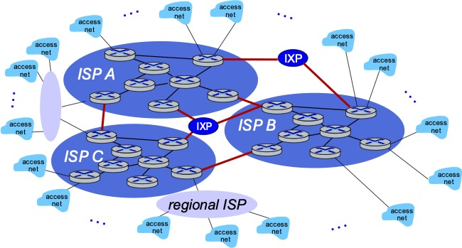

### network limitations/failures

- messages lost
- messages delayed/reordered
- messages limited in size
- messages corrupted

### dealing with network message lost

[figure not shown]

### handling lost message: acknowledgements

[figure not shown]

### handling lost message

[figure not shown]

### exercise: lost acknowledgement

exercise: how to fix this?

[figure not shown]

| A. | machine A needs to send ‘‘Got ‘got it!’ ’’ |
| --- | --- |
| B. | machine B should resend ‘‘Got it!’’ on its own |
| C. | machine A should resend the original message on its own |
| D. | none of these |

### answers

- send ‘‘Got ‘got it!’ ’’?
  - same problem: Now send ‘Got Got Got it’?
- resend ‘‘Got it!’’ own its own?
  - how many times? — B doesn’t have that info
- resend original message?
  - yes!
  - as far as machine A can see, *exact same situation* as losing original message

### lost acknowledgements

[figure not shown]

### delayed message

[figure not shown]

### delayed acknowledgements

[figure not shown]

### splitting messages: try 1

[figure not shown]

reconstructed message:  
The meeting is at 12pm.

### splitting messages: try 1 — problem 1

[figure not shown]

reconstructed message:  
The meetingThe meeting is at 12pm.

### exercise: other problems?

- other scenarios where we’d also have problems?

  | 1. | message (instead of acknowledgment) is lost |
  | --- | --- |
  | 2. | first message from machine A is delayed a long time by network |
  | 3. | acknowledgment of second message lost instead of first |

### splitting messages: try 2

[figure not shown]

reconstructed message:  
The meeting is at 12pm.

### splitting messages: try 2 — missed ack

[figure not shown]

reconstructed message:  
The meeting is at 12pm.

### splitting messages: try 2 — problem

[figure not shown]

A thinks: part 1 + part 2 acknowleged!

### splitting messages: version 3

[figure not shown]

### message corrupted

- corruption: e.g., a bit flip
  - sent: `I LIKE CATS` (`49204C494B452043415453`)
  - recv: `I LIKE BATS` (`49204C494B452042415453`)
- instead of sending ‘‘message’’, send ‘‘message’’ + checksum
  - checksum is some calculation using the original message
  - ex: checksum(`I LIKE CATS`) = 0xD9
  - send `49204C494B452043415453D9`
- receiver then also computes the checksum with the same data
  - if matches: keep the message
  - if does not match: pretend like the message was lost (i.e., drop the message)

### going faster

- so far: send one message, wait for acknowledgment
- very slow!
- instead, can send a bunch of parts and get them acknowledged together

### transmission window (ex: size 4)

[figure not shown]

Send a *window* of parts speculatively, then wait for ACKs.

### networking layers

| application | HTTP, SSH, SMTP, … | application-defined meanings |
| --- | --- | --- |
| transport | TCP, UDP, … | reach correct program reliability/streams |
| network | IPv4, IPv6 | reach correct machine (across networks) |
| link | Ethernet, Wi-Fi, … | coordinate shared wire/radio |
| physical | Ethernet, Wi-Fi, … | encode bits for wire/radio |

### transport layer protocols: UDP vs. TCP

- TCP: stream to other program
  - reliable transmission of as much data as you want
  - ‘‘connecting’’ fails if server not responding
  - write(fd, “a”, 1); write(fd, “b”, 1) = write(fd, “ab”, 2)
  - (at least) one socket per remote program being talked to
- UDP: messages sent to program, but no reliablity/streams
  - unreliable transmission of short messages
  - write(fd, “a”, 1); write(fd, “b”, 1) $\not=$ write(fd, “ab”, 2)
  - ‘‘connecting’’ just sets default destination
  - can sendto()/recvfrom() multiple other programs with one socket
    - (but don’t have to)

### upcoming lab

- request + receive message split into pieces
- you are responsible for:
  - requesting parts in order
  - resending requests if messages lost/corrupted
- ‘‘acknowledge’’ receiving part X to request part X+1

### protocol

- `GET(x)` — retrieve message $x$ (x = 0, 1, 2, or 3)
  - other end acknowledges by giving data
  - if they don’t reply, you need to send again
  - higher numbered messages have errors/etc. that are harder to handle
- `ACK(n)`
  - request message part $n + 1$ by acknowledging message part $n$
  - not quite same purpose as acknowledgments in prior examples
  - (in lab, the response is your ‘acknowledgment’ of your request;  
    you retry if you don’t get it)

### callback-based programming (1)

```
/* library code you don't write */
/* lab: part of waitForAllTimeoutsAndMessagesThenExit() */
void mainLoop() {
    while (notExiting) {
        Event event = waitForAndGetNextEvent();
        if (event.type == RECIEVED) {
            recvd(...);
        } else if (event.type == TIMEOUT) {
            (event.timeout_function)(...);
        }
        ...
    }
}
```

### callback-based programming (2)

```
/* your code, called by library */
void recvd(...) {
    ...
    setTimeout(..., timerCallback, ...);
}

void timerCallback(...) {
    ...
}

int main() {
    send(.../* first message */);
    ... /* other initial setup */
    waitForAllTimeoutsAndMessagesThenExit(); // runs mainLoop()
}
```

### callback-based programing (3)

```
packet = getNextPacket()
doSomething(packet);
sleep(10);
doAnotherThing();
packet = getNextPacket();
doYetAnotherThing(packet);
```

turns into code like:

```
afterTimeout() {
    doAnotherThing(); mode = 2;
}
recvdPacket(packet) {
    if (mode == 1) {
        doSomething(packet);
        setTimeout(10, afterTimeout);
    } else if (mode == 2)
        doYetAnotherThing(packet);
    } else ...
}
```

### callback-based programming uses

- writing scripts in a webpage
- many graphical user interface libraries
- sometimes servers that handle lots of connections

### mailbox model: importance of naming

- *mailbox* abstraction: send/receive messages

[figure not shown]

### names and addresses

| *name* | *address* |
| --- | --- |
| *logical identifier* | *location/how to locate* |
| variable `counter` | memory address `0x7FFF9430` |
| DNS name `www.virginia.edu` | IPv4 address `128.143.22.36` |
| DNS name `mail.google.com` | IPv4 address `216.58.217.69` |
| DNS name `mail.google.com` | IPv6 address `2607:f8b0:4004:80b::2005` |
| DNS name `cso2.cs.virginia.edu` | IPv4 address `128.143.67.91` |
| DNS name `cso2.cs.virginia.edu` | MAC address `18:66:da:2e:7f:da` |
| service name `https` | port number `443` |
| service name `ssh` | port number `22` |

### the network layer

- the Internet Protocol (IP) version 4 or version 6
  - there are also others, but quite uncommon today
- allows send messages to/recv messages from other networks
  - ‘‘internetwork’’
- messages called ‘‘packets’’

### IPv6 addresses

- IPv6 like IPv4, but with 128-bit numbers
- written in hex, 16-bit parts, seperated by colons (`:`)
- strings of 0s represented by double-colons (`::`)
- typically given to users in blocks of $2^{80}$ or $2^{64}$ addresses
  - no need for address translation?
- `2607:f8b0:400d:c00::6a` =  
  `2607:f8b0:400d:0c00:0000:0000:0000:006a`
  - `2607f8b0400d0c0000000000000006a`$_\text{SIXTEEN}$

### global routing

- IP addresses identify machines on the global internet
- address grouped geographically
  - for example, 100.128.0.0-100.255.255.255 all used in the US
- routing: finding a path for packets from source to destination across internet
  - *routers* are network equipment that send packets to other routers
  - routers advertise what IP address ranges they can route to
  - intuition: get packets closer with each hop
- analogy: airplane routing
  - want to fly CHO to LAX
  - route: CHO-ATL-LAX
- routing protocols determine routes from all sources to all destinations

### IPv4 addresses and forwarding

[figure not shown]

### networking layers

| application | HTTP, SSH, SMTP, … | application-defined meanings |
| --- | --- | --- |
| transport | TCP, UDP, … | reach correct program reliability/streams |
| network | IPv4, IPv6 | reach correct machine (across networks) |
| link | Ethernet, Wi-Fi, … | coordinate shared wire/radio |
| physical | Ethernet, Wi-Fi, … | encode bits for wire/radio |

### connections in TCP/IP

- connection identified by *4-tuple*
  - used by OS to lookup ‘‘where is the socket?’’
- (local IP address, local port, remote IP address, remote port)
- local IP address, port number can be set with `bind()` function
  - *typically* always done for servers, not done for clients
  - system will choose default if you don’t

### port numbers

- we run multiple programs on a machine
  - IP addresses identifying machine — not enough
- so, add 16-bit *port numbers*
  - think: multiple PO boxes at address
- 0–49151: typically assigned for particular services
  - 80 = http, 443 = https, 22 = ssh, …
- 49152–65535: allocated on demand
  - default ‘‘return address’’ for client connecting to server

### names and addresses

| *name* | *address* |
| --- | --- |
| *logical identifier* | *location/how to locate* |
| variable `counter` | memory address `0x7FFF9430` |
| DNS name `www.virginia.edu` | IPv4 address `128.143.22.36` |
| DNS name `mail.google.com` | IPv4 address `216.58.217.69` |
| DNS name `mail.google.com` | IPv6 address `2607:f8b0:4004:80b::2005` |
| DNS name `cso2.cs.virginia.edu` | IPv4 address `128.143.67.91` |
| DNS name `cso2.cs.virginia.edu` | MAC address `18:66:da:2e:7f:da` |
| service name `https` | port number `443` |
| service name `ssh` | port number `22` |

### DNS: Domain Name System

[figure not shown]

### URL / URIs

- Uniform Resource Locators (URL)
  - tells how to find ‘‘resource’’ on network
  - uniform — one syntax for multiple protocols (types of servers, etc.)
- Unifrom Resources Identifiers
  - superset of URLs

### URI examples

```
https://kytos02.cs.virginia.edu:443/cs3130-spring2023/quizzes/quiz.php?qid=02#q2

https://kytos02.cs.virginia.edu/cs3130-spring2023/quizzes/quiz.php?qid=02

https://www.cs.virginia.edu/

sftp://cr4bd@portal.cs.virginia.edu/u/cr4bd/file.txt

tel:+1-434-982-2200

//www.cs.virginia.edu/~cr4bd/3130/S2023/

/~cr4bd/3130/S2023
```

### URI generally

```
scheme://authority/path?query#fragment
```

- scheme: — what protocol
- //authority/
  - authority = user@host:port OR host:port OR user@host OR host
- path
  - which resource
- ?query — usually key/value pairs
- #fragment — place in resource
- most components (sometimes) optional

### HTTP: HyperText Transfer Protocol

- primary application-layer protocol for the Web
  - introduced in 1991
  - version 1.1 in 1997, version 2 in 2015, version 3 in 2022
- text-based protocol
- standard port: 80 (non-encrypted), 443 (encrypted)
- uses TCP (or TCP + TLS for encrypted version)
- client-server protocol
  - server = always on machine, never initiaites contact
  - client = sometimes on machine, initiates contact
- ex. URL: `http://www.foo.com/bar`

### HTTP: HyperText Transfer Protocol

- `http://www.foo.com/bar`
- HTTP client (example: web browser):
  - does a DNS lookup for www.foo.com (gets 123.156.189.12)
  - connects via TCP to 123.156.189.12 port 80
  - sends something like:

    ```
    GET /bar HTTP/1.1
    Host: www.foo.com
    ...
    ```

- server replies with status code + (usually) some data
  - 200 OK, 403 Unauthorized, 404 Not Found, 500 Internal Server Error, …

### HTTP

- GET — get resource
- POST — sending forms
- HEAD — get metadata about file (without getting its data)
- PUT, DELETE, …
- all requests/replies have many possible headers
  - filetype inforation
  - login-related information (usually)
  - metadata used for caching webpages
  - …

### networking layers

| application | HTTP, SSH, SMTP, … | application-defined meanings |
| --- | --- | --- |
| transport | TCP, UDP, … | reach correct program reliability/streams |
| network | IPv4, IPv6 | reach correct machine (across networks) |
| link | Ethernet, Wi-Fi, … | coordinate shared wire/radio |
| physical | Ethernet, Wi-Fi, … | encode bits for wire/radio |

### why IPv4 and IPv6?

- ran out of IPv4 addresses
  - $2^{32}$ *seemed* like a lot of addresses
  - now there are more internet *users* than addresses
- possible solutions:
  - IPv6: use more bits for addresses, enough to never run out
    - pro: clean, scalable solution that will always work
    - con: every thing on the network needs to be updated
  - NAT: user one IPv4 address for an entire network of devices
    - pro: can be implemented by any network
    - con: essentially a hack

### NAT: network address translation

- *convert* many private addresses to one public address
  - within the local network: use private IP addresses for local addresses
  - outside the local network: private IP addresses become a single public one
    - public address: address that can be routed on the internet
- commonly how home networks work (and some ISPs)
- certain IPv4 address blocks reserved for private/internal use
  - `192.168.X.X`
  - `172.16.X.X`–`172.31.X.X`
  - `10.X.X.X`
  - …

### you can see this yourself!

- on your computer:
  - go to https://whatismyipaddress.com/
  - go to your computer’s network settings and look at the IP address
- they don’t match!
  - difference between the public and private address
  - public address might match your colleagues’

### NAT idea

[figure not shown]

### NAT illusion

- NAT illusion:
- private IP address communicating directly with public IP
- inside network, talking to outside:
  - use private local address
  - use public remote address
  - never see router’s address
- outside network, talking to inside
  - use public local address
  - use router’s public address

### implementing NAT

| remote host + port | outside local port number | inside IP | inside port number |
| --- | --- | --- | --- |
| 128.148.17.3:443 | 54033 | 192.168.1.5 | 43222 |
| 11.7.17.3:443 | 53037 | 192.168.1.5 | 33212 |
| 128.148.31.2:22 | 54032 | 192.168.1.37 | 43010 |
| 128.148.17.3:443 | 63039 | 192.168.1.37 | 32132 |

- table of the translations
- need to update as new connections made

### networking layers

| application | HTTP, SSH, SMTP, … | application-defined meanings |
| --- | --- | --- |
| transport | TCP, UDP, … | reach correct program reliability/streams |
| network | IPv4, IPv6 | reach correct machine (across networks) |
| link | Ethernet, Wi-Fi, … | coordinate shared wire/radio |
| physical | Ethernet, Wi-Fi, … | encode bits for wire/radio |

# Backup slides

### The Internet

- Perhaps the most successful computer application ever
- Can you name a computer program that doesn’t use the internet?

[output not shown]

[output not shown]

[output not shown]

### the link layer

- Ethernet, Wi-Fi, Bluetooth, DOCSIS (cable modems), …
- allows send/recv messages to machines on ‘‘same’’ network segment
  - typically: wireless range+channel or connected to a single switch/router
  - could be larger (if *bridging* multiple network segments)
  - could be smaller (switch/router uses ‘‘virtual LANs’’)
- typically: source+destination specified with MAC addresses
  - MAC = media access control
  - usually manufacturer assigned / hard-coded into device
  - unique address per port/wifi transmitter/etc.
- can specify destination of ‘‘anyone’’ (called *broadcast*)
- messages usually called ‘‘frames’’

### link layer jobs

- divide raw bits into messages
- identify who message is for on shared radio/wire
- handle if two+ machines use radio/wire at same time
- drop/resend messages if corruption detected
  - resending more common in radio schemes (wifi, etc.)

### link layer reliablity?

- Ethernet + Wifi have checksums
- Q1: Why doesn’t this give us uncorrupted messages?
  - Why do we still have checksums at the higher layers?
- Q2: What’s a benefit of doing this if we’re also doing it in the higher layer?

### link layer quality of service

if frame gets…

| event | on Ethernet | on WiFi |
| --- | --- | --- |
| collides with another | detected + may resend | resend |
| not received | lose silently | resent |
| header corrupted | usually discard silently | usually resend |
| data corrupted | usually discard silently | usually resend |
| too long | not allowed to send | not allowed to send |
| reordered (v. other messages) | received out of order | received out of order |
| destination unknown | lose silently | usually resend?? |
| too much being sent | discard excess? | discard excess? |

### network layer quality of service

if packet …

[output not shown]

### firewalls

- don’t want to expose network service to everyone?
- solutions:
  - service picky about who it accepts connections from
  - filters in OS on machine with services
  - filters on router
- later two called ‘‘firewalls’’

### firewall rules examples?

- ALLOW tcp port 443 (https) FROM everyone
- ALLOW tcp port 22 (ssh) FROM *my desktop’s IP address*
- BLOCK tcp port 22 (ssh) FROM everyone else
- ALLOW from address X to address Y
- …

### TCP state machine

- TIME_WAIT, ESTABLISHED, …?
- OS tracks ‘‘state’’ of TCP connection
  - am I just starting the connection?
  - is other end ready to get data?
  - am I trying to close the connection?
  - do I need to resend something?
- standardized set of state names

### TIME_WAIT

- remember delayed messages?
- problem for TCP ports
- if I reuse port number, I can get message from old connection
- solution: TIME_WAIT to make sure connection really done
  - done after sending last message in connection

### querying the root

```
$ dig +trace +all www.cs.virginia.edu
...
edu.            172800  IN  NS  b.edu-servers.net.
edu.            172800  IN  NS  f.edu-servers.net.
edu.            172800  IN  NS  i.edu-servers.net.
edu.            172800  IN  NS  a.edu-servers.net.
...
b.edu-servers.net.  172800  IN  A   191.33.14.30
b.edu-servers.net.  172800  IN  AAAA    2001:503:231d::2:30
f.edu-servers.net.  172800  IN  A   192.35.51.30
f.edu-servers.net.  172800  IN  AAAA    2001:503:d414::30
...
;; Received 843 bytes from 198.97.190.53#53(h.root-servers.net) in 8 ms
...
```

### querying the edu

```
$ dig +trace +all www.cs.virginia.edu
...
virginia.edu.       172800  IN  NS  nom.virginia.edu.
virginia.edu.       172800  IN  NS  uvaarpa.virginia.edu.
virginia.edu.       172800  IN  NS  eip-01-aws.net.virginia.edu.
nom.virginia.edu.   172800  IN  A   128.143.107.101
uvaarpa.virginia.edu.   172800  IN  A   128.143.107.117
eip-01-aws.net.virginia.edu. 172800 IN  A   44.234.207.10
;; Received 165 bytes from 192.26.92.30#53(c.edu-servers.net) in 40 ms
...
```

### querying virginia.edu+cs.virginia.edu

```
$ dig +trace +all www.cs.virginia.edu
...
cs.virginia.edu.    3600    IN  NS  coresrv01.cs.virginia.edu.
coresrv01.cs.virginia.edu. 3600 IN  A   128.143.67.11
;; Received 116 bytes from 44.234.207.10#53(eip-01-aws.net.virginia.edu) in 72 ms

www.cs.Virginia.EDU.    172800  IN  A   128.143.67.11
cs.Virginia.EDU.    172800  IN  NS  coresrv01.cs.Virginia.EDU.
coresrv01.cs.Virginia.EDU. 172800 IN    A   128.143.67.11
;; Received 151 bytes from 128.143.67.11#53(coresrv01.cs.virginia.edu) in 4 ms
```

### querying typical ISP’s resolver

```
$ dig www.cs.virginia.edu
...
;; ANSWER SECTION:
www.cs.Virginia.EDU.      7183  IN  A   128.143.67.11
..
```

- cached response
- valid for 7183 more seconds
- after that everyone needs to check again

### ‘connected’ UDP sockets

```
int fd = socket(AF_INET, SOCK_DGRAM, 0);
struct sockaddr_in my_addr= ...;
/* set local IP address + port */
bind(fd, &my_addr, sizeof(my_addr))
struct sockaddr_in to_addr = ...;
connect(fd, &to_addr); /* set remote IP address + port */
    /* doesn't actually communicate with remote address yet */
...
int count = write(fd, data, data_size);
// OR
int count = send(fd, data, data_size, 0 /* flags */);
    /* single message -- sent ALL AT ONCE */

int count = read(fd, buffer, buffer_size);
// OR
int count = recv(fd, buffer, buffer_size, 0 /* flags */);
    /* receives whole single message ALL AT ONCE */
```

### UDP sockets on IPv4

```
int fd = socket(AF_INET, SOCK_DGRAM, 0);
struct sockaddr_in my_addr= ...;
/* set local IP address + port */
if (0 != bind(fd, &my_addr, sizeof(my_addr)))
    handle_error();
...
struct sockaddr_in to_addr = ...;
    /* send a message to specific address */
int bytes_sent = sendto(fd, data, data_size, 0 /* flags */,
    &to_addr, sizeof(to_addr));

struct sockaddr_in from_addr = ...;
    /* receive a message + learn where it came from */
int bytes_recvd = recvfrom(fd, &buffer[0], buffer_size, 0,
    &from_addr, sizeof(from_addr));
...
```

### routes on my desktop

```
$ /sbin/route -n
Kernel IP routing table
Destination     Gateway         Genmask         Flags Metric Ref    Use Iface
0.0.0.0         128.143.67.1    0.0.0.0         UG    100    0        0 enp0s31f6
128.143.67.0    0.0.0.0         255.255.255.0   U     100    0        0 enp0s31f6
169.254.0.0     0.0.0.0         255.255.0.0     U     1000   0        0 enp0s31f6
```

- network configuration says:
- (line 2) to get to 128.143.67.0–128.143.67.255, send directly on local network
  - ‘‘genmask’’ is mask (for bitwise operations) to specify how big range is
- (line 3) to get to 169.254.0.0–169.254.255.255, send directly on local network
- (line 1) to get anywhere else, use ‘‘gateway’’ 128.143.67.1

### two types of addresses?

- MAC addreses: on link layer
- IP addresses: on network layer
- how do we know which MAC address to use?

### a table on my desktop

my desktop:

```
$ arp -an
? (128.143.67.140) at 3c:e1:a1:18:bd:5f [ether] on enp0s31f6
? (128.143.67.236) at <incomplete> on enp0s31f6
? (128.143.67.11) at 30:e1:71:5f:39:10 [ether] on enp0s31f6
? (128.143.67.92) at <incomplete> on enp0s31f6
? (128.143.67.5) at d4:be:d9:b0:99:d1 [ether] on enp0s31f6
```

…

- network address to link-layer address + interface
- only tracks things directly connected to my local network
  - non-local traffic sent to local router

### URLs and HTTP (1)

- `http://www.foo.com:80/foo/bar?quux#q1`
- lookup IP address of www.foo.com
- connect via TCP to port 80:

[output not shown]

- exercise: why include the Host there?

### spoofing

- if I only allow connections from my desktop’s IP addresses,  
  how would you attack this?
- hint: how do we know what address messages come from?

### connection setup: server, manual

```
int server_socket_fd = socket(AF_INET, SOCK_STREAM, IPPROTO_TCP);
struct sockaddr_in addr;
addr.sin_family = AF_INET;
addr.sin_addr.s_addr = INADDR_ANY; /* "any address I can use" */
    /* or: addr.s_addr.in_addr = INADDR_LOOPBACK (127.0.0.1) */
    /* or: addr.s_addr.in_addr = htonl(...); */
addr.sin_port = htons(9999); /* port number 9999 */

if (bind(server_socket_fd, &addr, sizeof(addr)) < 0) {
    /* handle error */
}
listen(server_socket_fd, MAX_NUM_WAITING);
...
int socket_fd = accept(server_socket_fd, NULL);
```

[figure not shown]

### connection setup: client — manual addresses

```
int sock_fd;

server = /* code on later slide */;
sock_fd = socket(
    AF_INET, /* IPv4 */
    SOCK_STREAM, /* byte-oriented */
    IPPROTO_TCP
);
if (sock_fd < 0) { /* handle error */ }

struct sockaddr_in addr;
addr.sin_family = AF_INET;
addr.sin_addr.s_addr = htonl(2156872459); /* 128.143.67.11 */
addr.sin_port = htons(80); /* port 80 */
if (connect(sock_fd, (struct sockaddr*) &addr, sizeof(addr)) {
    /* handle error */
}
DoClientStuff(sock_fd); /* read and write from sock_fd */
close(sock_fd);
```

[figure not shown]

### echo client/server

```
void client_for_connection(int socket_fd) {
    int n; char send_buf\[MAX_SIZE]; char recv_buf\[MAX_SIZE];
    while (prompt_for_input(send_buf, MAX_SIZE)) {
        n = write(socket_fd, send_buf, strlen(send_buf));
        if (n != strlen(send_buf)) {...error?...}
        n = read(socket_fd, recv_buf, MAX_SIZE);
        if (n <= 0) return; // error or EOF
        write(STDOUT_FILENO, recv_buf, n);
    }
}
```

```
void server_for_connection(int socket_fd) {
    int read_count, write_count; char request_buf\[MAX_SIZE];
    while (1) {
        read_count = read(socket_fd, request_buf, MAX_SIZE);
        if (read_count <= 0) return; // error or EOF
        write_count = write(socket_fd, request_buf, read_count);
        if (read_count != write_count) {...error?...}
    }
}
```

### connection setup: server, address setup

```
/* example (hostname, portname) = ("127.0.0.1", "443") */
const char *hostname; const char *portname;
...
struct addrinfo *server;
struct addrinfo hints;
int rv;

memset(&hints, 0, sizeof(hints));
hints.ai_family = AF_INET; /* for IPv4 */
/* or: */ hints.ai_family = AF_INET6; /* for IPv6 */
/* or: */ hints.ai_family = AF_UNSPEC; /* I don't care */
hints.ai_flags = AI_PASSIVE;

rv = getaddrinfo(hostname, portname, &hints, &server);
if (rv != 0) { /* handle error */ }
```

[figure not shown]

### connection setup: server, addrinfo

```
struct addrinfo *server;
... getaddrinfo(...) ...

int server_socket_fd = socket(
    server->ai_family,
    server->ai_sockttype,
    server->ai_protocol
);

if (bind(server_socket_fd, ai->ai_addr, ai->ai_addr_len)) < 0) {
    /* handle error */
}
listen(server_socket_fd, MAX_NUM_WAITING);
...
int socket_fd = accept(server_socket_fd, NULL);
```

### connection setup: client, using addrinfo

```
int sock_fd;
struct addrinfo *server = /* code on next slide */;

sock_fd = socket(
    server->ai_family,
     // ai_family = AF_INET (IPv4) or AF_INET6 (IPv6) or ...
    server->ai_socktype,
     // ai_socktype = SOCK_STREAM (bytes) or ...
    server->ai_prototcol
     // ai_protocol = IPPROTO_TCP or ...
);
if (sock_fd < 0) { /* handle error */ }
if (connect(sock_fd, server->ai_addr, server->ai_addrlen) < 0) {
    /* handle error */
}
freeaddrinfo(server);
DoClientStuff(sock_fd); /* read and write from sock_fd */
close(sock_fd);
```

[figure not shown]

### connection setup: lookup address

```
/* example hostname, portname = "www.cs.virginia.edu", "443" */
const char *hostname; const char *portname;
...
struct addrinfo *server;
struct addrinfo hints;
int rv;
memset(&hints, 0, sizeof(hints));
hints.ai_family = AF_UNSPEC; /* for IPv4 OR IPv6 */
// hints.ai_family = AF_INET4; /* for IPv4 only */

hints.ai_socktype = SOCK_STREAM; /* byte-oriented --- TCP */
rv = getaddrinfo(hostname, portname, &hints, &server);
if (rv != 0) { /* handle error */ }

/* eventually freeaddrinfo(result) */
```

[figure not shown]

### connection setup: multiple server addresses

```
struct addrinfo *server;
...
rv = getaddrinfo(hostname, portname, &hints, &server);
if (rv != 0) { /* handle error */ }

for (struct addrinfo *current = server; current != NULL;
      current = current->ai_next) {
    sock_fd = socket(current->ai_family, current->ai_socktype, current->ai_protocol);
    if (sock_fd < 0) continue;
    if (connect(sock_fd, current->ai_addr, current->ai_addrlen) == 0) {
        break;
    }
    close(sock_fd); // connect failed
}
freeaddrinfo(server);
DoClientStuff(sock_fd);
close(sock_fd);
```

[figure not shown]

### connection setup: old lookup function

```
/* example hostname, portnum= "www.cs.virginia.edu", 443*/
const char *hostname; int portnum;
...
struct hostent *server_ip;
server_ip = gethostbyname(hostname);

if (server_ip == NULL) { /* handle error */ }

struct sockaddr_in addr;
addr.s_addr = *(struct in_addr*) server_ip->h_addr_list[0];
addr.sin_port = htons(portnum);
sock_fd = socket(AF_INET, SOCK_STREAM, IPPROTO_TCP);
connect(sock_fd, &addr, sizeof(addr));
...
```

### aside: on server port numbers

- Unix convention: must be `root` to use ports 0–1023
  - root = superuser = ‘adminstrator user’ = what sudo does
- so, for testing: probably ports $>$ 1023